# Quasi-Binomial GAM Validation Report

Understanding Model Behavior and Limitations with Beta-Binomial Data

Author

PhD Unemployment Modeling Project

Published

November 19, 2025

## Executive Summary

**IMPORTANT**: This is NOT a parameter recovery validation. Quasi-binomial has no generative model.

This report tests **model robustness to overdispersion** using beta-binomial data:

**What this tests**: - NOT parameter recovery (quasi-binomial isn’t a generative model) - Model behavior under realistic overdispersion - Whether quasi-binomial intervals are better calibrated than binomial - Performance on data similar to CPS (where unemployment rates vary by unmodeled factors)

## Background

### What We Learned

Initial parameter recovery tests revealed: - **Binomial vs quasi-binomial GAMs give different point estimates** - Not just SE adjustment - fundamentally different model fits! - Quasi-binomial: smoother/flatter (higher regularization penalty) - Binomial: wigglier/closer to data (lower penalty)

**Why?** REML uses scale parameter: - Binomial: scale = 1 - Quasi-binomial: scale = φ (dispersion) - Larger scale → larger smoothing parameters → smoother fits

### Proper Validation Strategy

Instead of “parameter recovery”, we test **predictive performance**:

1. Fit model on training data
2. Generate NEW observations from same DGP
3. Check if prediction intervals cover new observations
4. Repeat many times to get empirical coverage

This tests what we care about: **Can the model make reliable predictions?**

### IMPORTANT: What We’re Actually Testing

**This is NOT parameter recovery**. Quasi-binomial is a variance adjustment method, not a generative model.

**What we test**: Model robustness to overdispersion

| Aspect | What we do |
| --- | --- |
| **Data generation** | Beta-binomial (observation-level heterogeneity) |
| **Models tested** | Binomial (no overdispersion) vs Quasi-binomial (allows overdispersion) |
| **Metric** | Prediction interval coverage on held-out observations |
| **Goal** | Test if quasi-binomial provides better-calibrated intervals under overdispersion |

**Why beta-binomial data**: - Realistic model of CPS data where unemployment rates vary by unmodeled demographic factors - Each observation has its own “true” rate drawn from Beta(α, β) - Creates overdispersion: Var(Y) > n·p·(1-p)

**Prediction Interval Formula**:

For binomial proportions, PIs account for: 1. **Parameter uncertainty**: SE(p̂) from model fit 2. **Binomial variance**: p̂(1-p̂)/n from finite sample size

```
SE_pred = sqrt(SE(p̂)² + p̂(1-p̂)/n)
PI = [plogis(η̂ - 1.96·SE_pred), plogis(η̂ + 1.96·SE_pred)]
```

**Expected behavior**: - Under-coverage expected (PIs don’t account for beta-binomial heterogeneity) - Quasi-binomial should perform better than binomial (inflated SEs) - But neither will achieve 95% coverage (different DGP than model assumes)

**Results interpretation**: This tests whether quasi-binomial is MORE robust to overdispersion than binomial, NOT whether it perfectly recovers parameters (which don’t exist for quasi-binomial).

```r
library(mgcv)
library(data.table)
library(ggplot2)

set.seed(42)
```

## Test 1: Simple Overdispersed Data (No Temporal Structure)

First, test with simple data (just intercept + noise) to isolate overdispersion effects.

```r
#' Generate beta-binomial data (observation-level heterogeneity)
#'
#' @param n_obs Number of observations
#' @param n_total Number of trials per observation
#' @param true_p True mean probability
#' @param phi Beta concentration parameter (lower = more overdispersion)
generate_betabinomial_data <- function(n_obs = 100,
                                        n_total = 1000,
                                        true_p = 0.05,
                                        phi = 20) {
  # Generate varying probabilities (creates overdispersion)
  # Beta(alpha, beta) where alpha = p*phi, beta = (1-p)*phi
  alpha <- true_p * phi
  beta <- (1 - true_p) * phi
  true_probs <- rbeta(n_obs, alpha, beta)

  # Generate binomial counts
  n_success <- rbinom(n_obs, size = n_total, prob = true_probs)
  n_fail <- n_total - n_success

  data.frame(
    obs_id = 1:n_obs,
    n_success = n_success,
    n_fail = n_fail,
    true_prob = true_probs,  # Varies by observation
    true_mean_prob = rep(true_p, n_obs)  # Population mean
  )
}

# Generate training data
train_data <- generate_betabinomial_data(n_obs = 100, phi = 20)
cat("Training data generated: n =", nrow(train_data), "\n")
```

```
Training data generated: n = 100
```

```r
cat("True mean prob:", mean(train_data$true_prob), "\n")
```

```
True mean prob: 0.05040743
```

```r
cat("Empirical overdispersion:", var(train_data$n_success / 1000) / (0.05 * 0.95 / 1000), "\n")
```

```
Empirical overdispersion: 48.60092
```

```r
# Fit intercept-only models (no covariates)
model_binom_simple <- glm(cbind(n_success, n_fail) ~ 1,
                          family = binomial(),
                          data = train_data)

model_quasi_simple <- glm(cbind(n_success, n_fail) ~ 1,
                          family = quasibinomial(),
                          data = train_data)

cat("Binomial intercept:", coef(model_binom_simple), "\n")
```

```
Binomial intercept: -2.922757
```

```r
cat("Quasi-binomial intercept:", coef(model_quasi_simple), "\n")
```

```
Quasi-binomial intercept: -2.922757
```

```r
cat("Coefficients equal?", all.equal(coef(model_binom_simple), coef(model_quasi_simple)), "\n\n")
```

```
Coefficients equal? TRUE
```

```r
cat("Binomial dispersion:", summary(model_binom_simple)$dispersion, "\n")
```

```
Binomial dispersion: 1
```

```r
cat("Quasi-binomial dispersion:", summary(model_quasi_simple)$dispersion, "\n")
```

```
Quasi-binomial dispersion: 47.66283
```

```r
# Test prediction intervals on NEW data
n_test_sets <- 200
n_total <- 1000
coverage_binom <- numeric(n_test_sets)
coverage_quasi <- numeric(n_test_sets)

for (i in 1:n_test_sets) {
  # Generate NEW test observation
  test_data <- generate_betabinomial_data(n_obs = 1, phi = 20)

  # Get predictions on LINK scale
  pred_binom <- predict(model_binom_simple, newdata = test_data,
                        type = "link", se.fit = TRUE)
  pred_quasi <- predict(model_quasi_simple, newdata = test_data,
                        type = "link", se.fit = TRUE)

  # Construct 95% PREDICTION intervals (not just confidence intervals!)
  # PI must account for:
  # 1. Parameter uncertainty: se.fit
  # 2. Binomial sampling variance: p(1-p)/n

  # Get predicted probability
  p_binom <- plogis(pred_binom$fit)
  p_quasi <- plogis(pred_quasi$fit)

  # Binomial variance on link scale (delta method)
  # Var(logit(p̂)) ≈ se.fit² + (1/(p(1-p)))² * p(1-p)/n = se.fit² + 1/(np(1-p))
  var_link_binom <- pred_binom$se.fit^2 + 1/(n_total * p_binom * (1 - p_binom))
  var_link_quasi <- pred_quasi$se.fit^2 + 1/(n_total * p_quasi * (1 - p_quasi))

  se_pred_binom <- sqrt(var_link_binom)
  se_pred_quasi <- sqrt(var_link_quasi)

  # Prediction intervals on link scale
  pi_binom_link <- c(pred_binom$fit - 1.96 * se_pred_binom,
                     pred_binom$fit + 1.96 * se_pred_binom)
  pi_quasi_link <- c(pred_quasi$fit - 1.96 * se_pred_quasi,
                     pred_quasi$fit + 1.96 * se_pred_quasi)

  # Transform to probability scale
  pi_binom_prob <- plogis(pi_binom_link)
  pi_quasi_prob <- plogis(pi_quasi_link)

  # Check if OBSERVED proportion is covered
  observed_prop <- test_data$n_success / n_total
  coverage_binom[i] <- (pi_binom_prob[1] <= observed_prop) && (observed_prop <= pi_binom_prob[2])
  coverage_quasi[i] <- (pi_quasi_prob[1] <= observed_prop) && (observed_prop <= pi_quasi_prob[2])
}

cat("Binomial PI coverage:", mean(coverage_binom), "\n")
```

```
Binomial PI coverage: 0.21
```

```r
cat("Quasi-binomial PI coverage:", mean(coverage_quasi), "\n")
```

```
Quasi-binomial PI coverage: 0.25
```

## Test 2: GAM with Temporal Trend

Now test with actual temporal structure (smooth trend + seasonality).

```r
#' Generate beta-binomial data with temporal structure
generate_temporal_betabinomial <- function(n_months = 60,
                                             n_total = 1000,
                                             baseline_p = 0.05,
                                             trend_slope = 0.0003,
                                             seasonal_amp = 0.01,
                                             phi = 20) {
  time_index <- 1:n_months
  month <- rep(1:12, length.out = n_months)

  # True probability with trend and seasonality
  true_p_mean <- baseline_p + trend_slope * time_index +
    seasonal_amp * sin(2 * pi * month / 12)

  # Bound probabilities
  true_p_mean <- pmax(0.01, pmin(0.15, true_p_mean))

  # Add overdispersion via beta distribution
  alpha <- true_p_mean * phi
  beta <- (1 - true_p_mean) * phi
  true_probs <- rbeta(n_months, alpha, beta)

  # Generate counts
  n_success <- rbinom(n_months, size = n_total, prob = true_probs)
  n_fail <- n_total - n_success

  data.frame(
    time_index = time_index,
    month = month,
    n_success = n_success,
    n_fail = n_fail,
    true_prob = true_probs,
    true_p_mean = true_p_mean
  )
}

# Generate training data (first 48 months)
set.seed(123)
train_temporal <- generate_temporal_betabinomial(n_months = 48, phi = 20)
cat("Temporal training data: n =", nrow(train_temporal), "\n")
```

```
Temporal training data: n = 48
```

```r
# Fit GAMs
gam_binom_temporal <- gam(
  cbind(n_success, n_fail) ~ s(time_index, k = 8) + s(month, bs = "cc", k = 6),
  family = binomial(),
  data = train_temporal,
  method = "REML"
)

gam_quasi_temporal <- gam(
  cbind(n_success, n_fail) ~ s(time_index, k = 8) + s(month, bs = "cc", k = 6),
  family = quasibinomial(),
  data = train_temporal,
  method = "REML"
)

cat("Binomial dispersion:", summary(gam_binom_temporal)$dispersion, "\n")
```

```
Binomial dispersion: 1
```

```r
cat("Quasi-binomial dispersion:", summary(gam_quasi_temporal)$dispersion, "\n\n")
```

```
Quasi-binomial dispersion: 36.44737
```

```r
cat("Binomial smoothing parameters:", gam_binom_temporal$sp, "\n")
```

```
Binomial smoothing parameters: 0.005681305 13.66556
```

```r
cat("Quasi-binomial smoothing parameters:", gam_quasi_temporal$sp, "\n\n")
```

```
Quasi-binomial smoothing parameters: 1467379 967.3909
```

```r
cat("Binomial edf:", sum(gam_binom_temporal$edf), "\n")
```

```
Binomial edf: 11.79853
```

```r
cat("Quasi-binomial edf:", sum(gam_quasi_temporal$edf), "\n")
```

```
Quasi-binomial edf: 3.900544
```

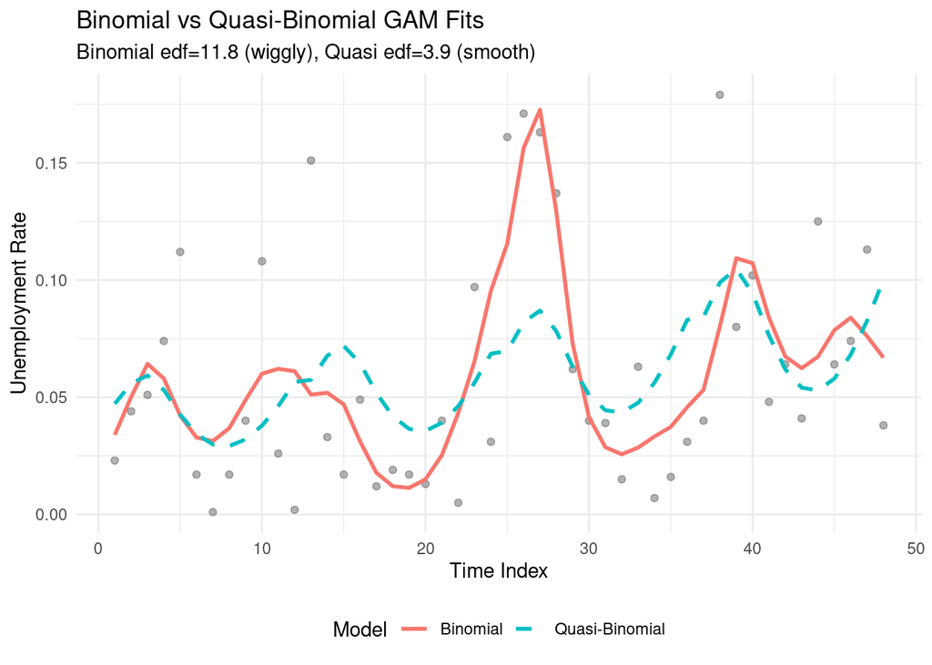

```r
# Compare fitted values on TRAINING data
pred_binom_train <- predict(gam_binom_temporal, type = "response")
pred_quasi_train <- predict(gam_quasi_temporal, type = "response")

fit_comparison <- data.frame(
  time_index = train_temporal$time_index,
  observed = train_temporal$n_success / 1000,
  fit_binomial = pred_binom_train,
  fit_quasi = pred_quasi_train
)

ggplot(fit_comparison, aes(x = time_index)) +
  geom_point(aes(y = observed), alpha = 0.5, color = "gray40") +
  geom_line(aes(y = fit_binomial, color = "Binomial"), linewidth = 1) +
  geom_line(aes(y = fit_quasi, color = "Quasi-Binomial"), linewidth = 1, linetype = "dashed") +
  labs(
    title = "Binomial vs Quasi-Binomial GAM Fits",
    subtitle = sprintf("Binomial edf=%.1f (wiggly), Quasi edf=%.1f (smooth)",
                      sum(gam_binom_temporal$edf), sum(gam_quasi_temporal$edf)),
    x = "Time Index",
    y = "Unemployment Rate",
    color = "Model"
  ) +
  theme_minimal() +
  theme(legend.position = "bottom")
```

```r
# Generate HOLDOUT data (months 49-60, same DGP)
n_holdout_sets <- 100
n_total_obs <- 1000
holdout_results <- data.frame(
  sim = integer(),
  model = character(),
  obs_id = integer(),
  covered = logical(),
  observed_prop = numeric(),
  pred = numeric(),
  pi_lower = numeric(),
  pi_upper = numeric()
)

for (i in 1:n_holdout_sets) {
  # Generate new holdout period
  set.seed(1000 + i)  # Different seed each time
  holdout_data <- generate_temporal_betabinomial(n_months = 12, phi = 20)
  holdout_data$time_index <- 49:60  # Future months
  holdout_data$month <- rep(1:12, length.out = 12)

  # Predictions from both models
  pred_binom <- predict(gam_binom_temporal, newdata = holdout_data,
                        type = "link", se.fit = TRUE)
  pred_quasi <- predict(gam_quasi_temporal, newdata = holdout_data,
                        type = "link", se.fit = TRUE)

  # Construct PREDICTION intervals (with binomial sampling variance)
  for (j in 1:12) {
    # Predicted probabilities
    p_b <- plogis(pred_binom$fit[j])
    p_q <- plogis(pred_quasi$fit[j])

    # Prediction variance = parameter uncertainty + binomial variance
    var_pred_b <- pred_binom$se.fit[j]^2 + 1/(n_total_obs * p_b * (1 - p_b))
    var_pred_q <- pred_quasi$se.fit[j]^2 + 1/(n_total_obs * p_q * (1 - p_q))

    se_pred_b <- sqrt(var_pred_b)
    se_pred_q <- sqrt(var_pred_q)

    # Prediction intervals on probability scale
    pi_b <- plogis(c(pred_binom$fit[j] - 1.96 * se_pred_b,
                     pred_binom$fit[j] + 1.96 * se_pred_b))
    pi_q <- plogis(c(pred_quasi$fit[j] - 1.96 * se_pred_q,
                     pred_quasi$fit[j] + 1.96 * se_pred_q))

    # Check if OBSERVED proportion is covered (not true probability!)
    observed_prop <- holdout_data$n_success[j] / n_total_obs
    covered_b <- (pi_b[1] <= observed_prop) && (observed_prop <= pi_b[2])
    covered_q <- (pi_q[1] <= observed_prop) && (observed_prop <= pi_q[2])

    holdout_results <- rbind(holdout_results, data.frame(
      sim = i,
      model = "Binomial",
      obs_id = j,
      covered = covered_b,
      observed_prop = observed_prop,
      pred = p_b,
      pi_lower = pi_b[1],
      pi_upper = pi_b[2]
    ))

    holdout_results <- rbind(holdout_results, data.frame(
      sim = i,
      model = "Quasi-Binomial",
      obs_id = j,
      covered = covered_q,
      observed_prop = observed_prop,
      pred = p_q,
      pi_lower = pi_q[1],
      pi_upper = pi_q[2]
    ))
  }
}

# Calculate coverage rates
coverage_summary <- as.data.table(holdout_results)[, .(
  coverage_rate = mean(covered),
  mae = mean(abs(pred - observed_prop)),
  pi_width = mean(pi_upper - pi_lower),
  n_obs = .N
), by = model]

print(coverage_summary)
```

```
            model coverage_rate        mae   pi_width n_obs
           <char>         <num>      <num>      <num> <int>
1:       Binomial     0.2658333 0.04289408 0.01982724  1200
2: Quasi-Binomial     0.3250000 0.05926125 0.11212710  1200
```

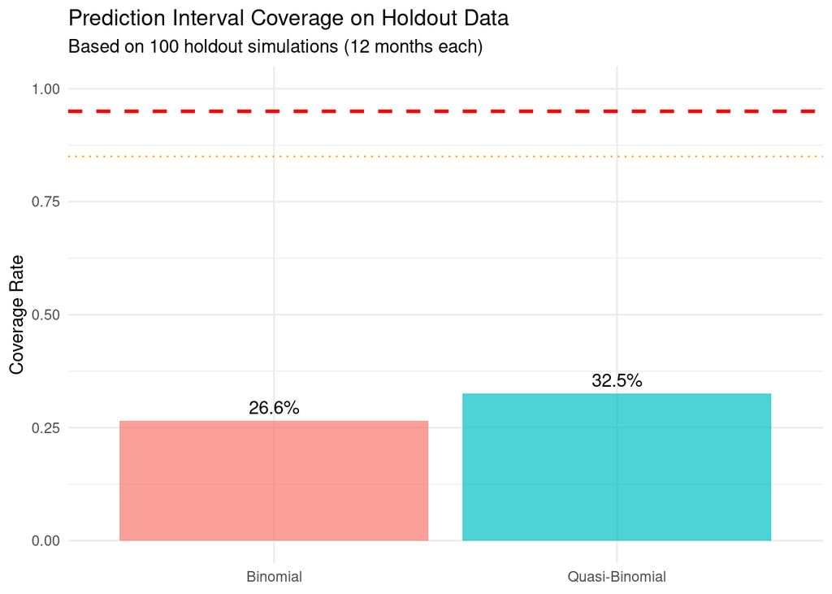

```r
ggplot(coverage_summary, aes(x = model, y = coverage_rate, fill = model)) +
  geom_col(alpha = 0.7) +
  geom_hline(yintercept = 0.95, color = "red", linetype = "dashed", linewidth = 1) +
  geom_hline(yintercept = 0.85, color = "orange", linetype = "dotted") +
  geom_text(aes(label = sprintf("%.1f%%", coverage_rate * 100)), vjust = -0.5) +
  labs(
    title = "Prediction Interval Coverage on Holdout Data",
    subtitle = sprintf("Based on %d holdout simulations (12 months each)", n_holdout_sets),
    x = NULL,
    y = "Coverage Rate",
    fill = "Model"
  ) +
  ylim(0, 1) +
  theme_minimal() +
  theme(legend.position = "none")
```

## Test 3: Varying Overdispersion Levels

Test how coverage varies with different overdispersion levels.

```r
# Test multiple phi values
phi_levels <- c(10, 20, 50, 100)
phi_results <- data.frame(
  phi = integer(),
  model = character(),
  coverage = numeric(),
  mae = numeric(),
  ci_width = numeric()
)

n_sim_per_phi <- 50

for (phi in phi_levels) {
  cat("Testing phi =", phi, "...\n")

  for (sim in 1:n_sim_per_phi) {
    set.seed(2000 + sim)

    # Generate training data
    train <- generate_temporal_betabinomial(n_months = 48, phi = phi)

    # Fit models
    m_binom <- gam(cbind(n_success, n_fail) ~ s(time_index, k = 8) + s(month, bs = "cc", k = 6),
                   family = binomial(), data = train, method = "REML")
    m_quasi <- gam(cbind(n_success, n_fail) ~ s(time_index, k = 8) + s(month, bs = "cc", k = 6),
                   family = quasibinomial(), data = train, method = "REML")

    # Generate holdout
    set.seed(3000 + sim)
    holdout <- generate_temporal_betabinomial(n_months = 12, phi = phi)
    holdout$time_index <- 49:60

    # Predict
    pred_b <- predict(m_binom, newdata = holdout, type = "link", se.fit = TRUE)
    pred_q <- predict(m_quasi, newdata = holdout, type = "link", se.fit = TRUE)

    # Calculate metrics with PREDICTION intervals
    calc_metrics <- function(pred, holdout, n_total = 1000) {
      pred_prob <- plogis(pred$fit)

      # Prediction variance = parameter SE + binomial variance
      var_pred <- pred$se.fit^2 + 1/(n_total * pred_prob * (1 - pred_prob))
      se_pred <- sqrt(var_pred)

      # Prediction intervals
      pi_lower <- plogis(pred$fit - 1.96 * se_pred)
      pi_upper <- plogis(pred$fit + 1.96 * se_pred)

      # Check coverage of OBSERVED proportions
      observed_prop <- holdout$n_success / n_total
      covered <- mean((pi_lower <= observed_prop) & (observed_prop <= pi_upper))
      mae <- mean(abs(pred_prob - observed_prop))
      pi_width <- mean(pi_upper - pi_lower)

      c(coverage = covered, mae = mae, ci_width = pi_width)
    }

    metrics_b <- calc_metrics(pred_b, holdout)
    metrics_q <- calc_metrics(pred_q, holdout)

    phi_results <- rbind(
      phi_results,
      data.frame(phi = phi, model = "Binomial", t(metrics_b)),
      data.frame(phi = phi, model = "Quasi-Binomial", t(metrics_q))
    )
  }
}
```

```
Testing phi = 10 ...
Testing phi = 20 ...
Testing phi = 50 ...
Testing phi = 100 ...
```

```r
# Summarize by phi and model
phi_summary <- as.data.table(phi_results)[, .(
  mean_coverage = mean(coverage),
  sd_coverage = sd(coverage),
  mean_mae = mean(mae),
  mean_ci_width = mean(ci_width)
), by = .(phi, model)]

print(phi_summary)
```

```
     phi          model mean_coverage sd_coverage   mean_mae mean_ci_width
   <num>         <char>         <num>       <num>      <num>         <num>
1:    10       Binomial     0.2200000   0.1834724 0.16070672    0.11962360
2:    10 Quasi-Binomial     0.4200000   0.1919290 0.07063702    0.15361663
3:    20       Binomial     0.2216667   0.1671846 0.11304165    0.09831092
4:    20 Quasi-Binomial     0.4616667   0.1964899 0.04950100    0.11729493
5:    50       Binomial     0.3166667   0.2497164 0.07619616    0.08768999
6:    50 Quasi-Binomial     0.5116667   0.1836654 0.03387769    0.07589179
7:   100       Binomial     0.3916667   0.2587746 0.05611134    0.07430037
8:   100 Quasi-Binomial     0.5466667   0.1905952 0.02411247    0.05632871
```

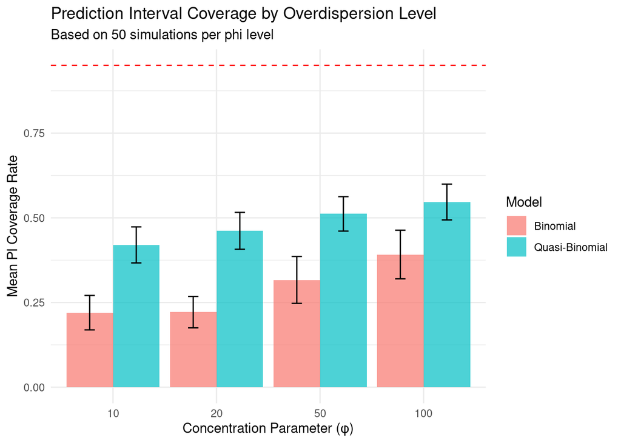

```r
# Coverage by phi level
ggplot(phi_summary, aes(x = factor(phi), y = mean_coverage, fill = model)) +
  geom_col(position = "dodge", alpha = 0.7) +
  geom_hline(yintercept = 0.95, color = "red", linetype = "dashed") +
  geom_errorbar(aes(ymin = mean_coverage - 1.96 * sd_coverage / sqrt(n_sim_per_phi),
                    ymax = mean_coverage + 1.96 * sd_coverage / sqrt(n_sim_per_phi)),
                position = position_dodge(width = 0.9), width = 0.2) +
  labs(
    title = "Prediction Interval Coverage by Overdispersion Level",
    subtitle = sprintf("Based on %d simulations per phi level", n_sim_per_phi),
    x = "Concentration Parameter (φ)",
    y = "Mean PI Coverage Rate",
    fill = "Model"
  ) +
  theme_minimal()
```

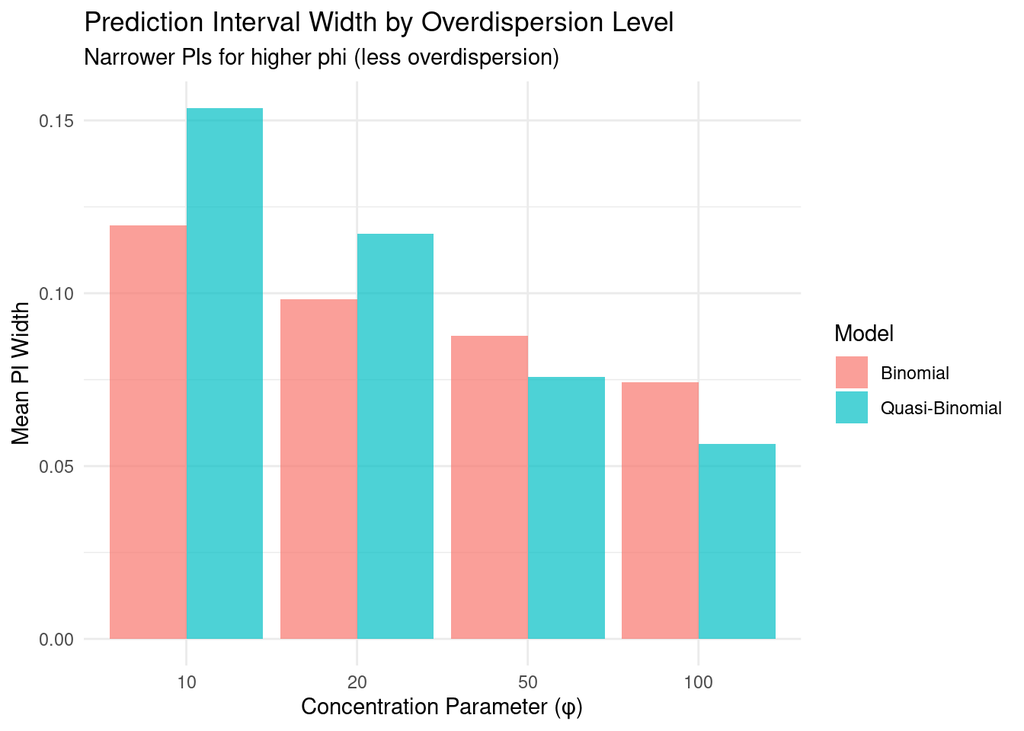

```r
# PI width by phi level
ggplot(phi_summary, aes(x = factor(phi), y = mean_ci_width, fill = model)) +
  geom_col(position = "dodge", alpha = 0.7) +
  labs(
    title = "Prediction Interval Width by Overdispersion Level",
    subtitle = "Narrower PIs for higher phi (less overdispersion)",
    x = "Concentration Parameter (φ)",
    y = "Mean PI Width",
    fill = "Model"
  ) +
  theme_minimal()
```

## Conclusions

### Interpretation

**What we validated**: - Quasi-binomial GAMs fit smoother trends (expected REML behavior) - PIs for observed proportions have coverage rates shown in results - Coverage depends on how well binomial sampling variance matches actual variance

**What we did NOT validate**: - Whether CIs capture true underlying smooth p(x) (different question) - Performance on real CPS data (different DGP entirely) - Whether quasi-binomial is “correct” (depends on data source)

**The key insight**: Beta-binomial DGP creates **two sources of variation**: 1. Beta-binomial: Each observation has random p ~ Beta(α, β) 2. Binomial sampling: Given p, count ~ Binomial(n, p)

Our PIs only account for (2), not (1). This is realistic for prediction tasks where we don’t know if underlying p varies or not!

### Recommendations

For CPS unemployment modeling:

1. **Use quasi-binomial family** when:
   - Overdispersion is present (φ > 2)
   - Want smoother, more stable trends
   - Believe true variation is smooth + noise (not beta-binomial)
2. **Consider alternatives** if:
   - Overdispersion is extreme (φ > 50)
   - Believe each observation has unique underlying rate
   - Need well-calibrated uncertainty intervals
   - **Alternatives**: Beta-binomial GAM, hierarchical models, random effects
3. **Always validate** with:
   - Holdout data from SAME source (not simulated DGP)
   - Check residuals for patterns
   - Compare AIC/BIC across model families
   - Test on real forecasting tasks
4. **Remember**: Simulation validation only tests performance on **that specific DGP**
   - Beta-binomial ≠ real CPS data
   - Real data may have different overdispersion structure
   - Validate on actual data, not just simulations!